# Solutions to Applied Predictive Modeling (Kuhn and Johnson, 2013)

Chapter 12 - Exercise 12.2

by Brian Hassett

# Introduction

This exercise gets at an important issue in classification, namely severe class imbalance. The actual remedies for this are not dealt with until **Chapter 16**, so this data allows us to explore the potential issues this causes in terms of creating samples, dealing with rare classes and choosing a data splitting strategy. **Exercise 4.4** has already dealt with creating samples and using stratification to ensure that the samples are representative and that rare classes are included. Therefore in this exercise I will look at data splitting and implementing a model. In the original paper, Brodnjak-Vonina et al. (2005)[^1], the authors train models on the data we have available in this exercise. They also apply the model to a separate test set and make predictions. I have extracted that test data from the paper and also applied my model to it. My training and test results are similar to the authors.

# Exercise Instructions

*Instructions adapted from Kuhn and Johnson (2013)[^2].*

In **Exercise 4.4**, we described a data set which contained 96 oil samples each from one of seven types of oils (pumpkin, sunflower, peanut, olive, soybean, rapeseed, and corn). Gas chromatography was performed on each sample and the percentage of each type of 7 fatty acids was determined. We would like to use these data to build a model that predicts the type of oil based on a sample’s fatty acid percentages.

1. Like the hepatic injury data, these data suffer from extreme imbalance. Given this imbalance, should the data be split into training and test sets?
2. Which classification statistic would you choose to optimize for this exercise and why?

# Setup

```r
# Load packages
library(AppliedPredictiveModeling)
library(caret)
library(ggbiplot) # load before tidyverse to avoid issues with plyr vs dplyr
library(tidyverse)
library(tidymodels)
library(discrim)
library(ggcorrplot)

# Load my functions:
source("/home/brian/R/dir/Util/bh_functions.R")

# Options:
theme_set(theme_bw())
options(digits = 4)
```

# (a)

Based on the data it seems that leave-one-out cross-validation (LOOCV) would be the best option here. This way each class will be represented in each resample. The rarest class is `G`, but there are two observations with class `G` which means that even if one class `G` observation is chosen to be left out there will still be one observation to be trained on. Computation time is typically an issue with LOOCV, but the data set is small ($n = 96$, $p = 7$) so it shouldn’t be an issue here.

**NOTE:** `tidymodels` does have a method for splitting data for LOOCV (`rsample::loo_cv()`), however the various functions for fitting models do not actually implement LOOCV. It is computationally expensive and it may not have good statistical properties and so it hasn’t been prioritized for implementation[^3]. Therefore I have manually implemented LOOCV using a mixture of `tidymodels` objects and regular `R` code. I have chosen to implement just one model for now, namely linear discriminant analysis (LDA). The LDA model can be used for multi-class problems and can be used to make a prediction on one observation at a time (multinomial logistic regression seems to have issues in this regard). Also, Brodnjak-Vonina et al. (2005) use LDA and LOOCV to establish a baseline, so I can compare my results to theirs.

# (b)

Since this is a multi-class problem and there is a large class imbalance, the accuracy rate alone may not be ideal. This is because simply predicting the most popular classes is likely to get a good result. Cohen’s Kappa takes into account the class distributions of the training samples and the accuracy that would be generated simply by chance. I will calculate the accuracy rate *and* Kappa for this exercise.

# Data

The data is stored in two different objects: the predictors are stored in `fattyAcids`; the class labels are in `oilTypes`. Combine these into one data set:

```r
# Load data:
data("oil")

# Combine predictors and class labels:
df1 <- cbind(fattyAcids, oilType) %>%
  set_names(c(str_to_lower(names(fattyAcids)), 'y')) # the class is renamed to y

# View data:
df1
```

|  | palmitic | stearic | oleic | linoleic | linolenic | eicosanoic | eicosenoic | y |
| --- | --- | --- | --- | --- | --- | --- | --- | --- |
| 1 | 9.7 | 5.2 | 31.0 | 52.7 | 0.4 | 0.4 | 0.1 | A |
| 2 | 11.1 | 5.0 | 32.9 | 49.8 | 0.3 | 0.4 | 0.1 | A |
| 3 | 11.5 | 5.2 | 35.0 | 47.2 | 0.2 | 0.4 | 0.1 | A |
| 4 | 10.0 | 4.8 | 30.4 | 53.5 | 0.3 | 0.4 | 0.1 | A |
| 5 | 12.2 | 5.0 | 31.1 | 50.5 | 0.3 | 0.4 | 0.1 | A |
| 6 | 9.8 | 4.2 | 43.0 | 39.2 | 2.4 | 0.4 | 0.5 | A |
| 7 | 10.5 | 5.0 | 31.8 | 51.3 | 0.4 | 0.4 | 0.1 | A |
| 8 | 10.5 | 5.0 | 31.8 | 51.3 | 0.4 | 0.4 | 0.1 | A |
| 9 | 11.5 | 5.2 | 35.0 | 47.2 | 0.2 | 0.4 | 0.1 | A |
| 10 | 10.0 | 4.8 | 30.4 | 53.5 | 0.3 | 0.4 | 0.1 | A |

[output cut: 86 more lines]

# EDA

Plot the distribution of the response class (oil types):

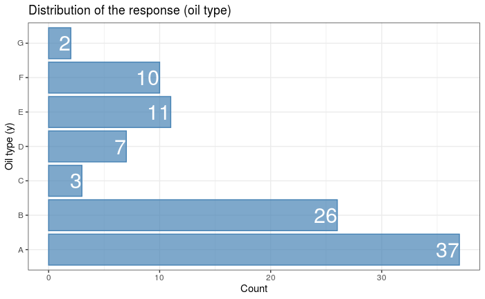

```r
df1 %>%
  count(y) %>%
  ggplot() +
  geom_col(aes(y, n),
           fill = "steelblue", color = "steelblue", alpha = 0.7) +
  geom_text(aes(y, n, label = n),
            hjust = 1, size = 8,
            color = "white") +
  labs(x = "Oil type (y)", y = "Count", title = "Distribution of the response (oil type)") +
  coord_flip()
```

Distributions of the seven fatty acids which serve as the predictors (all numerical):

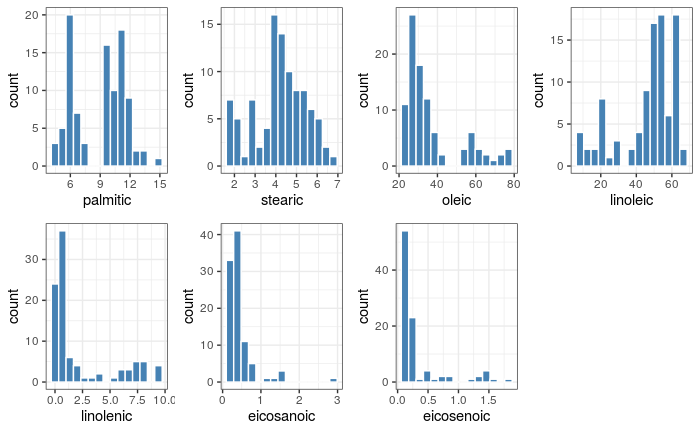

```r
bh_plot_histogram_grid(df1, nrow = 2, bins = 15)
```

There are some skewed distributions.

It’s not clear if any transforming would be required.

# Preprocessing

There are no zero variance variables. However, two of the variables are highly correlated (negatively):

```r
correlations <- cor(df1[ , bh_numeric_cols(df1)], )
correlations
```

```
           palmitic  stearic    oleic linoleic linolenic eicosanoic eicosenoic
palmitic    1.00000  0.50637  0.03346  -0.1591  -0.26264   -0.01902    -0.3194
stearic     0.50637  1.00000 -0.56788   0.5143  -0.55678   -0.02582    -0.5153
oleic       0.03346 -0.56788  1.00000  -0.9777   0.24546    0.09676     0.4530
linoleic   -0.15912  0.51433 -0.97775   1.0000  -0.34165   -0.14195    -0.4739
linolenic  -0.26264 -0.55678  0.24546  -0.3417   1.00000   -0.01846     0.4290
eicosanoic -0.01902 -0.02582  0.09676  -0.1419  -0.01846    1.00000     0.5712
eicosenoic -0.31944 -0.51532  0.45303  -0.4739   0.42897    0.57119     1.0000
```

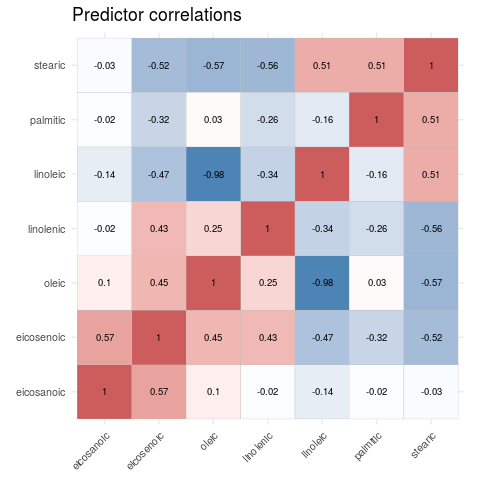

```r
ggcorrplot(correlations, hc.order = TRUE, show.legend = F,
                 colors = c("steelblue", "white", "indianred"),
                 lab = TRUE, lab_size = 2.5, digits = 2, tl.cex = 8) +
  ggtitle("Predictor correlations")
```

Therefore I will include `step_corr()` to filter for highly correlated variables in the model recipe.

# Modeling

Here I will implement LDA with LOOCV. For preprocessing, I will use `step_corr()`, which as we saw above will remove one predictor from the data.

```r
# Preprocessing
rec1 <-
  recipe(y ~ ., data = df1) %>%
  step_corr(all_predictors(), threshold = 0.9)

# Model
lda_mod <-
  discrim_linear() %>%
  set_mode("classification") %>%
  set_engine("MASS")

# Workflow
workflow <-
  workflow() %>%
  add_model(spec = lda_mod) %>%
  add_recipe(rec1)

# LOOCV
n <- nrow(df1)
preds <- c("")

for(i in 1:n) {
  fit1 <-
    workflow %>%
    fit(data = df1[-i, ])

  # Trace:
  if(i %% 10 == 0)
    print(paste0("Holding out observation no. ", i, " of ", n, "..."))

  preds[[i]] <- predict(fit1, new_data = df1[i, ]) %>%
                  pluck(".pred_class") %>%
                  as.character()
}
```

```
[1] "Holding out observation no. 10 of 96..."
[1] "Holding out observation no. 20 of 96..."
[1] "Holding out observation no. 30 of 96..."
[1] "Holding out observation no. 40 of 96..."
[1] "Holding out observation no. 50 of 96..."
[1] "Holding out observation no. 60 of 96..."
[1] "Holding out observation no. 70 of 96..."
[1] "Holding out observation no. 80 of 96..."
[1] "Holding out observation no. 90 of 96..."
```

# Metrics

Produce a confusion matrix of the predictions and actual classes, as well as the accuracy rate and Kappa statistic:

```r
metrics <- caret::confusionMatrix(data = factor(preds), reference = df1$y)
metrics$table
```

```
          Reference
Prediction  A  B  C  D  E  F  G
         A 34  1  0  0  0  0  0
         B  2 25  0  0  0  0  0
         C  0  0  3  0  0  0  0
         D  0  0  0  7  0  0  0
         E  1  0  0  0 11  0  0
         F  0  0  0  0  0 10  0
         G  0  0  0  0  0  0  2
```

```r
metrics$overall
```

```
      Accuracy          Kappa  AccuracyLower  AccuracyUpper   AccuracyNull AccuracyPValue  McnemarPValue
     9.583e-01      9.445e-01      8.967e-01      9.885e-01      3.854e-01      3.918e-33            NaN
```

The Kappa value is 0.9445.

It turns out that the accuracy (95.83%) is actually a good measure of performance because the model has not got stuck on predicting the most common classes. Rather it has predicted 92/96 held out observations correctly. It even correctly identified the two class `G` observations.

It also turns out that 92 observations correctly predicted is exactly the result the authors of the original paper got with LDA and LOOCV. The only difference is that I get a percentage of 92/96 = 95.83% while they report 92/95 = 96.84%. The exercise mentions that the authors of the paper seem to have miscounted the number of samples as the exercise also reports 96 training samples. See below where I read in the data from the original paper and count the unknown and known samples. In the paper, the observation that is incorrectly included in the unknown samples is the one with ID of 27. This is actually given a class of 2 by the paper authors in their own table 1.

See below for a quick comparison between my results and the paper where I perform PCA, and also compare predictions on the unknown samples by my LDA and the authors’ neural network model.

# Original article

In Brodnjak-Vonina et al. (2005), the authors use LDA and LOOCV on the training data ($n = 96$) to establish a baseline accuracy rate which they report at 96.84%. They also train a counterpropagation neural network in the same manner and report accuracy of 98.95%. This neural network is then applied to an unlabeled test set ($n = 37$) and probabilities are obtained. As the data is unlabeled, it’s not possible to directly asses the quality of the predictions. However, the authors compare the model predictions to the manufacturer’s description of each oil and find they correlate well.

In this section of the notebook I recreate some of the graphs and tables from the paper. Ultimately I use my LDA model to make predictions on the test data and compare the results to the authors’. All but two of predictions were in agreement.

## Read in data

The test data is not provided for the exercise, but I have scraped the data from the paper using the `tabulizer` package. This data contains both the known (training) and unknown (testing) samples which I will split up later:

```r
library(tabulizer)
pdf1 <- "/home/brian/R/dir/APM/articles/Brodnjak-Vonina D, Kodba Z, Novi M (2005). Multivariate Data Analysis in Classification of Vegetable Oils Characterized by the Content of Fatty Acids.pdf"
tbls <- extract_tables(pdf1, pages = 3:5)
```

[output not shown]

```r
# Extract and clean names:
names1 <- tbls[[1]][1, ] %>%
  str_to_lower()
names1[1] <- "id"
names1[2] <- "class"

# Combine tables into one data frame:
df2 <- map(tbls[1:3], data.frame) %>% # only the first three elements are actually tables
  bind_rows() %>%
  set_names(names1) %>%
  filter(id != "aID Class") %>%
  # The ID and Class columns are merged; split them:
  mutate(class = str_extract(id, "\\d$"),
         id = str_extract(id, "\\d{1,}")) %>%
  # Replace "< 0.1" with 0.1 in the "eico*" columns and convert all to numeric:
  dplyr::mutate(across(contains("eico"), function(col) str_replace(col, "< 0.1", "0.1"))) %>% # convert
  dplyr::mutate(across(3:9, as.numeric))
df2
```

| id | class | palmitic | stearic | oleic | linoleic | linolenic | eicosanoic | eicosenoic |
| --- | --- | --- | --- | --- | --- | --- | --- | --- |
| 1 | 1 | 9.7 | 5.2 | 31.0 | 52.7 | 0.4 | 0.4 | 0.1 |
| 2 | 1 | 11.1 | 5.0 | 32.9 | 49.8 | 0.3 | 0.4 | 0.1 |
| 3 | 1 | 11.5 | 5.2 | 35.0 | 47.2 | 0.2 | 0.4 | 0.1 |
| 4 | 1 | 10.0 | 4.8 | 30.4 | 53.5 | 0.3 | 0.4 | 0.1 |
| 5 | 1 | 12.2 | 5.0 | 31.1 | 50.5 | 0.3 | 0.4 | 0.1 |
| 6 | 1 | 9.8 | 4.2 | 43.0 | 39.2 | 2.4 | 0.4 | 0.5 |
| 7 | 1 | 10.5 | 5.0 | 31.8 | 51.3 | 0.4 | 0.4 | 0.1 |
| 8 | 1 | 10.5 | 5.0 | 31.8 | 51.3 | 0.4 | 0.4 | 0.1 |
| 9 | 1 | 11.5 | 5.2 | 35.0 | 47.2 | 0.2 | 0.4 | 0.1 |
| 10 | 1 | 10.0 | 4.8 | 30.4 | 53.5 | 0.3 | 0.4 | 0.1 |

[output cut: 122 more lines]

The breakdown of known and unknown classes is 96 to 36. This agrees with the exercise instructions. The authors of the paper say 95 and 37 which is strange as they seem to have miscounted their own data:

```r
df2 %>%
  dplyr::mutate(known_class = class > 0) %>%
  dplyr::count(known_class)
```

|  | known_class | n |
| --- | --- | --- |
| 1 | FALSE | 36 |
| 2 | TRUE | 96 |

## Recreate Table 2

Recreate Table 2 (page 36) which shows the correlation coefficients between percentage levels of seven fatty acids for all 132 samples:

```r
correlations2 <- as.matrix(df2[ , map_lgl(df2, is.numeric)]) %>%
  cor() %>%
  round(2)
correlations2
```

```
           palmitic stearic oleic linoleic linolenic eicosanoic eicosenoic
palmitic       1.00    0.53 -0.20     0.05     -0.20      -0.09      -0.39
stearic        0.53    1.00 -0.60     0.58     -0.59      -0.09      -0.59
oleic         -0.20   -0.60  1.00    -0.97      0.20       0.11       0.47
linoleic       0.05    0.58 -0.97     1.00     -0.34      -0.15      -0.51
linolenic     -0.20   -0.59  0.20    -0.34      1.00       0.07       0.53
eicosanoic    -0.09   -0.09  0.11    -0.15      0.07       1.00       0.59
eicosenoic    -0.39   -0.59  0.47    -0.51      0.53       0.59       1.00
```

Plot the data from Table 2:

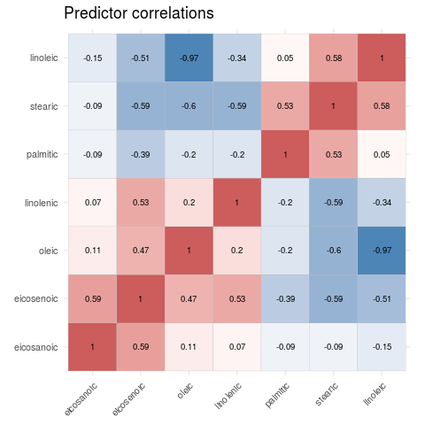

```r
ggcorrplot(correlations2, hc.order = TRUE, show.legend = F,
                 colors = c("steelblue", "white", "indianred"),
                 lab = TRUE, lab_size = 2.5, digits = 2, tl.cex = 8) +
  ggtitle("Predictor correlations")
```

## Recreate Fig. 2

Recreate Fig. 2 (page 36) which compares the `oleic` and `linoleic` acids which are highly correlated as seen above:

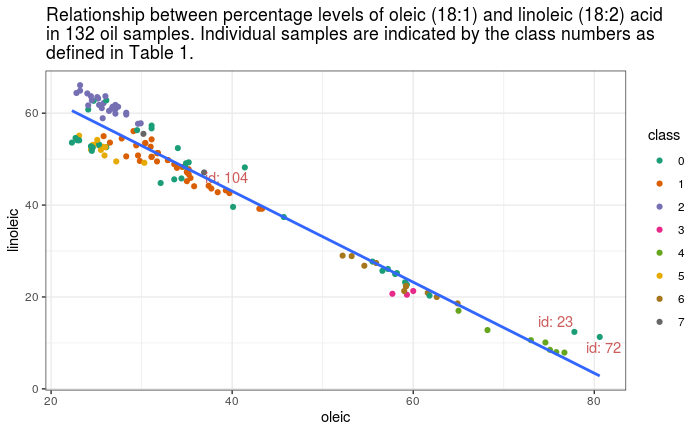

```r
df2 %>%
  ggplot(aes(oleic, linoleic)) +
  geom_point(aes(color = class)) +
  ggrepel::geom_text_repel(data = dplyr::filter(df2, id %in% c(23, 72, 104)),
                           aes(label = paste0("id: ", id)),
                           color = "indianred") +
  geom_smooth(method = "lm", se = FALSE) +
  scale_color_brewer(palette = "Dark2") +
  ggtitle(str_wrap("Relationship between percentage levels of oleic (18:1) and linoleic (18:2) acid in 132 oil samples. Individual samples are indicated by the class numbers as defined in Table 1."))
```

The three outlier points (with ID’s 23, 72 and 104) are unlabeled data. In the PCA analysis below they are also found to deviate from all other oil types.

## Recreate Table 3

Recreate Table 3 (page 37) which shows the results of principal components analysis:

```r
# PCA Analysis:
pca1 <- prcomp(as.matrix(df2[ , map_lgl(df2, is.numeric)]), scale. = F)

# Variance and Proportion of Variance Explained:
pca1_var <- pca1$sdev^2
pca1_pve <- (pca1_var/sum(pca1_var))

# Table 3:
table3 <- matrix(data = c(1:7, # PC no.
                          (100 * pca1_pve) %>% round(2), # %Var
                          100*cumsum(pca1_pve)), ncol = 3, byrow = FALSE) # Total
dimnames(table3) <- list(NULL, c("PC", "%Var", "Total"))
table3
```

```
     PC  %Var  Total
[1,]  1 95.09  95.09
[2,]  2  2.72  97.81
[3,]  3  1.98  99.79
[4,]  4  0.12  99.91
[5,]  5  0.07  99.98
[6,]  6  0.01  99.99
[7,]  7  0.01 100.00
```

## Fig 3

Recreate Fig. 3 (page 37) which is a biplot showing the results of principal components analysis:

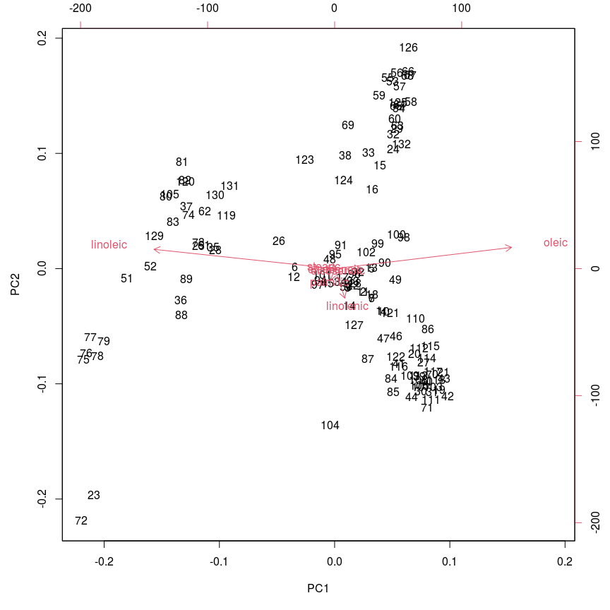

```r
# Base R:
pca1$x <- (-1)*pca1$x # invert to match the paper
biplot(pca1)
```

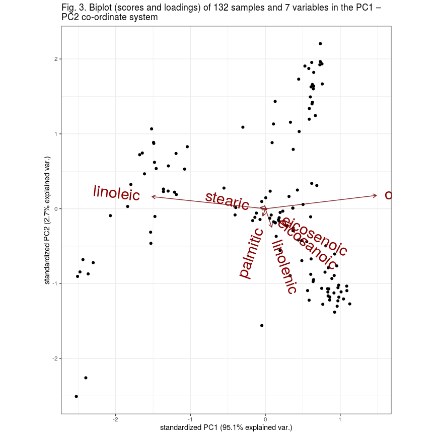

```r
# ggplot2 style:
ggbiplot(pca1, labels = df1$id, groups = df1$class, varname.size = 8) +
  scale_color_brewer(palette = "Dark2") +
  ggtitle(str_wrap("Fig. 3. Biplot (scores and loadings) of 132 samples and 7 variables in the PC1 – PC2 co-ordinate system"))
```

Notice how the three outliers identified above (with ID’s 23, 72 and 104) also deviate from the other samples in this plot.

# Predictions on unknown samples

The paper provides a test set in Table 5. These data are not labeled like the training data, however they have a brief description of the oil which serves as a guide for assessing the results of the predictions.

Filter out the unknown samples and create a test set: (the one with ID of 27 is included in the paper’s unknown samples but it actually has a class of 2 according to Table 1)

```r
df2_test <- df2 %>%
  filter(class == 0) # a class of 0 indicates an unknown sample
df2_test
```

| id | class | palmitic | stearic | oleic | linoleic | linolenic | eicosanoic | eicosenoic |
| --- | --- | --- | --- | --- | --- | --- | --- | --- |
| 22 | 0 | 6.7 | 3.4 | 35.2 | 49.3 | 3.6 | 0.4 | 0.5 |
| 23 | 0 | 3.8 | 3.9 | 77.8 | 12.4 | 0.2 | 0.3 | 0.2 |
| 24 | 0 | 10.1 | 4.7 | 26.1 | 52.6 | 5.2 | 0.4 | 0.2 |
| 25 | 0 | 4.9 | 2.2 | 58.2 | 25.2 | 7.1 | 0.6 | 1.2 |
| 26 | 0 | 6.1 | 2.7 | 45.7 | 37.4 | 5.9 | 0.5 | 0.8 |
| 28 | 0 | 5.9 | 2.4 | 55.5 | 27.7 | 6.2 | 0.6 | 1.1 |
| 29 | 0 | 10.9 | 3.8 | 25.3 | 53.0 | 5.6 | 0.4 | 0.2 |
| 37 | 0 | 5.2 | 2.0 | 59.3 | 22.7 | 8.2 | 0.6 | 1.3 |
| 38 | 0 | 8.3 | 3.5 | 33.6 | 45.6 | 6.3 | 0.4 | 0.6 |
| 61 | 0 | 5.1 | 2.0 | 57.2 | 26.1 | 6.9 | 0.7 | 1.4 |

[output cut: 26 more lines]

Make predictions using my LDA model:

```r
# First retrain the model on ALL of the training data:
fit2 <-
    workflow %>% # workflow and associated recipe already defined above
    fit(data = df1)

preds2 <- predict(fit2, new_data = df2_test) %>%
            pluck(".pred_class") %>%
            as.character()
```

To compare to the paper, I need to scrape the table of probabilities from the paper (Table 5, page 41):

```r
table5 <- extract_tables(pdf1, pages = 11)

probs <- table5 %>%
  data.frame() %>%
  tail(-1) %>% # drop first row which contains the column names
  set_names(c("Description", "no.", "id", "A", "B", "C", "D", "E", "F", "G")) %>% # manually set names
  dplyr::mutate(across(4:10, as.numeric)) %>%
  filter(id != 27)
probs
```

| Description | no. | id | A | B | C | D | E | F | G |
| --- | --- | --- | --- | --- | --- | --- | --- | --- | --- |
| Vegetable | 1 | 22 | 0.029 | 0.741 | 0 | 0.000 | 0.230 | 0.000 | 0.000 |
| Vegetable | 2 | 23 | 0.000 | 0.000 | 0 | 1.000 | 0.000 | 0.000 | 0.000 |
| Vegetable | 3 | 24 | 0.730 | 0.000 | 0 | 0.000 | 0.270 | 0.000 | 0.000 |
| Vegetable | 4 | 25 | 0.000 | 0.000 | 0 | 0.000 | 0.020 | 0.980 | 0.000 |
| Vegetable | 5 | 26 | 0.121 | 0.000 | 0 | 0.003 | 0.000 | 0.571 | 0.304 |
| Vegetable unrefined | 7 | 28 | 0.006 | 0.000 | 0 | 0.000 | 0.002 | 0.804 | 0.187 |
| Vegetable unrefined | 8 | 29 | 0.014 | 0.000 | 0 | 0.000 | 0.987 | 0.000 | 0.000 |
| Mixed pumpkin, vegetable | 9 | 37 | 0.000 | 0.000 | 0 | 0.000 | 0.000 | 1.000 | 0.000 |
| Vegetable | 10 | 38 | 0.000 | 0.000 | 0 | 0.000 | 0.816 | 0.178 | 0.007 |
| Vegetable | 11 | 61 | 0.002 | 0.000 | 0 | 0.000 | 0.001 | 0.980 | 0.017 |

[output cut: 26 more lines]

Obtain the predictions by taking the class with the highest probability: (use the `LETTERS` vector to convert to the letter version of the class)

```r
preds_paper <- LETTERS[apply(probs[ , 4:10], 1, FUN = which.max)]
preds_paper
```

```
 [1] "B" "D" "A" "F" "F" "F" "E" "F" "E" "F" "F" "E" "E" "E" "E" "E" "E" "E" "B" "B" "D" "F" "F" "B" "B" "B" "A" "B" "F" "B"
[31] "F" "E" "E" "E" "A" "A"
```

Confusion matrix of my predictions versus the paper’s:

```r
table(preds2, preds_paper)
```

```
      preds_paper
preds2  A  B  D  E  F
     A  3  0  0  0  0
     B  0  8  0  0  0
     D  0  0  2  0  0
     E  1  0  0 12  1
     F  0  0  0  0  9
```

Only two observations disagree

```r
agree <- (preds2 == preds_paper)
probs[!agree, ]
```

|  | Description | no. | id | A | B | C | D | E | F | G |
| --- | --- | --- | --- | --- | --- | --- | --- | --- | --- | --- |
| 3 | Vegetable | 3 | 24 | 0.73 | 0 | 0 | 0 | 0.270 | 0.000 | 0.000 |
| 31 | Mixed 50% soybean, 50% sunflower | 32 | 123 | 0.00 | 0 | 0 | 0 | 0.438 | 0.524 | 0.038 |

As can be seen, for the observations that my LDA model predicted differently, the max probability was not very close to one as it was in some cases. In both cases, my model predicted class `E` which is also the second highest probability in both cases.

My predictions:

```r
preds2[!agree]
```

```
[1] "E" "E"
```

# Conclusions

This exercise provided an imbalanced data set with some rare classes. This makes it difficult to apply standard data splitting approaches. Later chapters deal with more advanced methods to remedy the class imbalance, but this exercise is a chance to explore using leave-one-out cross-validation (LOOCV). This method is typically not preferred over other methods, but the small sample size means the computation time wasn’t prohibitive. I implemented a simple linear model (LDA) and was able to achieve very high accuracy on the training data. In particular the model was able to correctly predict the two samples from the rarest class during the LOOCV process. I also applied the model to a test set and was able to achieve comparable results to the more complex neural network model used by the authors of the original paper.

# Future work

It may be worth implementing some more linear and non-linear models on the data. This might require implementing a tuning method if I want to tune over a grid of parameters. However there is limited data and the LDA model used in this notebook achieved a high accuracy. Also, the LOOCV approach seems to be less useful in general so it may not be much help to have a working implementation.

[^1]: Brodnjak-Vonina D, Kodba Z, Novi M (2005). “Multivariate Data Analysis in Classification of Vegetable Oils Characterized by the Content of Fatty Acids.” Chemometrics and Intelligent Laboratory Systems, **75**(1), 31–43.
[^2]: Kuhn M, Johnson K (2013). *Applied Predictive Modeling*. Springer.
[^3]: https://www.tmwr.org/resampling.html#leave-one-out-cross-validation